# PM 606 Final Report: Key Mortality Phenotypes after Patient Discharge

Ashwath Raj

# Executive Summary/Problem Statement

This project originates from a study by the City of Hope, with analysis in partnership with USC’s Department of Preventative Medicine. The California Teacher Study (CTS), a combination of surveys and hospitalization records from 2000-2015, provides the data. The surveys include information about age, race, ethnicity, bmi, family history, diet, physical activity, and drug use). My goal is to develop the best fitting model, using machine learning, to classify patients’ likelihoods of dying within 30 and 60 days after discharge from the hospital. I use self-reported characteristics, referred to as phenotypes, and diagnosis info for this prediction.

# Methods

After merging the hospitalizations records and survey data, I start by forming and examining the dataset of all deceased patients. There is roughly equal number of people who died and who survived (~65000).I also examine their causes of death to identify if a reasonable distribution exists.

```
##
##     0     1
## 64099 68439
```

```
## # A tibble: 787 x 2
## # Groups:   cause_of_death_dsc [787]
##    cause_of_death_dsc                                      n
##    <chr>                                               <int>
##  1 Atherosclerotic heart disease                        5797
##  2 Alzheimer's disease, unspecified                     4522
##  3 Chronic obstructive pulmonary disease, unspecified   3100
##  4 Congestive heart failure                             2546
##  5 Malignant neoplasm of breast, unspecified            2518
##  6 Stroke, not specified as hemorrhage or infarction    2451
##  7 Acute myocardial infarction, unspecified             2449
##  8 Malignant neoplasm of bronchus or lung, unspecified  2253
##  9 Unspecified dementia                                 1814
## 10 Pneumonia, unspecified                               1767
## # ... with 777 more rows
```

# Analysis Approach

Initially, my approach was to find correlations between patient phenotypes against different causes of death and post-discharge mortality windows. I intended to focus on congestive heart failure, pneumonia, and breast cancer and incorporate sociological and survey qualities. While this is an intriguing set of questions, I eventually decided to prioritize prediction on 30 day and 60 discharge mortality windows.

I split the data into training, testing, and validation sets (65,30,5). I also used individual dataframes for the 30 day and 60 day groups. My variable selection included a variety of self-reported survey elements and hospital information. I paid particular attention to two metrics: minimizing the number of missing values (NAs) in the features I used and selecting features that might lead to significant physiological effects (e.g. daily steroidal medication use, invasive surgeries, bmi, exercise, smoking, pregnancy).

## Machine Learning Methods: Random Forests

I first utilized classification trees. I found that patient disposition codes (reason for admittance) and specific causes of death predict the percentage likelihood of the mortality window. Next, I found that both Random Forests and Multiclass methods didn’t perform well. Due to the class imbalance in the training data (one class being ten times larger), the model incorrectly achieved high accuracy by over-predicting patient survival. Similarly, in the Multiclass Random Forest, the model greatly over-selected the largest mortality window class (> 360 days).

```
##  [1] "cause_of_death_cde"      "ses_quartile_ind"
##  [3] "menarche_age"            "oralcntr_yrs"
##  [5] "preg_total_q1"           "meno_stattype"
##  [7] "allex_hrs_q1"            "allex_life_hrs"
##  [9] "vit_mulvit_q1"           "alchl_analyscat"
## [11] "smoke_expocat"           "smoke_statcat"
## [13] "smoke_lifeexpo"          "weight_q1"
## [15] "bmi_q1"                  "passmok_expocat"
## [17] "asthma_q3"               "insulin_daily"
## [19] "othhbp_daily"            "steroid_daily"
## [21] "brondil_daily"           "cholmed_daily"
## [23] "antidep_daily"           "alchl_g_dayrecen"
## [25] "diag_ccs_code1"          "diag_ccs_code2"
## [27] "blockgroup90_urban_cat"  "admission_typ"
## [29] "length_of_stay_day_cnt"  "dnr_flg"
## [31] "major_diag_cat_cde"      "patient_care_typ"
## [33] "patient_disposition_cde" "facility_flg"
## [35] "payer_cat_cde"           "payer_plan_cde"
## [37] "payer_coverage_typ"      "total_charges_amt"
## [39] "d60"
```

```
## n= 37307
##
## node), split, n, loss, yval, (yprob)
##       * denotes terminal node
##
##  1) root 37307 4682 FALSE (0.87450076 0.12549924)
##    2) patient_disposition_cde< 10.5 28580 1952 FALSE (0.93170049 0.06829951) *
##    3) patient_disposition_cde>=10.5 8727 2730 FALSE (0.68717772 0.31282228)
##      6) patient_disposition_cde>=11.5 6876  927 FALSE (0.86518325 0.13481675)
##       12) patient_disposition_cde< 12.5 6369  602 FALSE (0.90547967 0.09452033) *
##       13) patient_disposition_cde>=12.5 507  182 TRUE (0.35897436 0.64102564)
##         26) cause_of_death_cde=A047,C159,C189,C20,C221,C343,C437,C509,C541,C719,C921,D469,E43,F019,F03,G309,G311,G319,G35,G700,G950,I10,I119,I120,I131,I250,I251,I272,I48,I489,I495,I500,I509,I516,I671,I672,I694,I698,J101,J439,J441,J448,J984,K519,K750,M069,N180,N183,N189,N19,N312,N390,N649 232   90…
##         27) cause_of_death_cde=A099,A412,A419,C169,C180,C210,C259,C349,C439,C444,C480,C482,C519,C55,C56,C577,C64,C679,C709,C73,C762,C80,C819,C831,C833,C859,C911,C920,C950,C959,D432,D519,D649,E119,E142,E149,E46,E668,E854,E859,G008,G122,G20,G300,G934,I071,I110,I219,I259,I350,I38,I429,I499,I609,I614…
##      7) patient_disposition_cde< 11.5 1851   48 TRUE (0.02593193 0.97406807) *
```

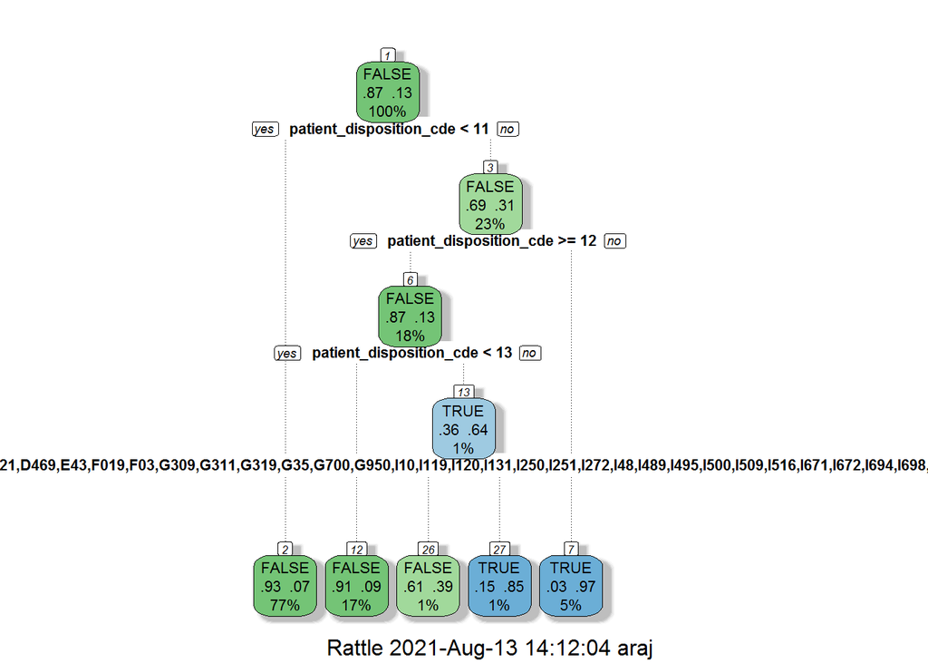

```
##
## FALSE  TRUE
## 21271  2978
```

```
##
## Call:
##  randomForest(formula = d30 ~ ., data = died_30.g$train, sampsize = c(2978,      2978))
##                Type of random forest: classification
##                      Number of trees: 500
## No. of variables tried at each split: 6
##
##         OOB estimate of  error rate: 12.89%
## Confusion matrix:
##       FALSE TRUE class.error
## FALSE 19183 2088  0.09816182
## TRUE   1037 1941  0.34822028
```

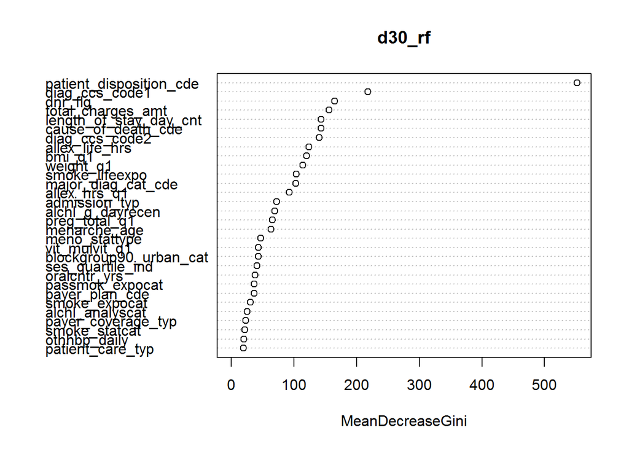

```
##
## FALSE  TRUE
## 23209  1040
```

```
##
## Call:
##  randomForest(formula = d60 ~ ., data = died_60.g$train, sampsize = c(1040,      1040))
##                Type of random forest: classification
##                      Number of trees: 500
## No. of variables tried at each split: 6
##
##         OOB estimate of  error rate: 15.63%
## Confusion matrix:
##       FALSE TRUE class.error
## FALSE 20150 3059   0.1318023
## TRUE    732  308   0.7038462
```

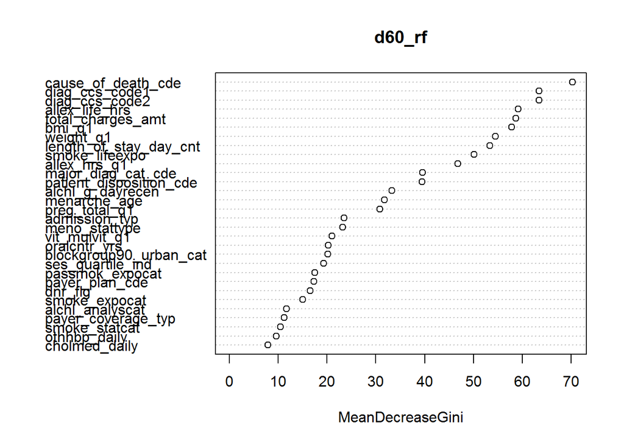

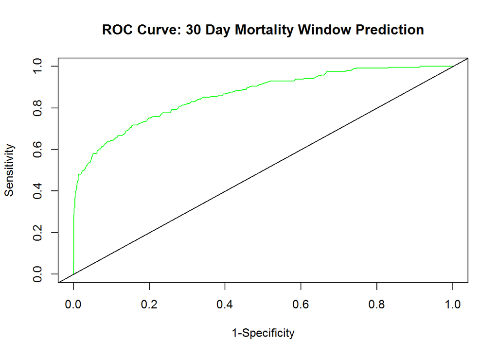

```
## integer(0)
```

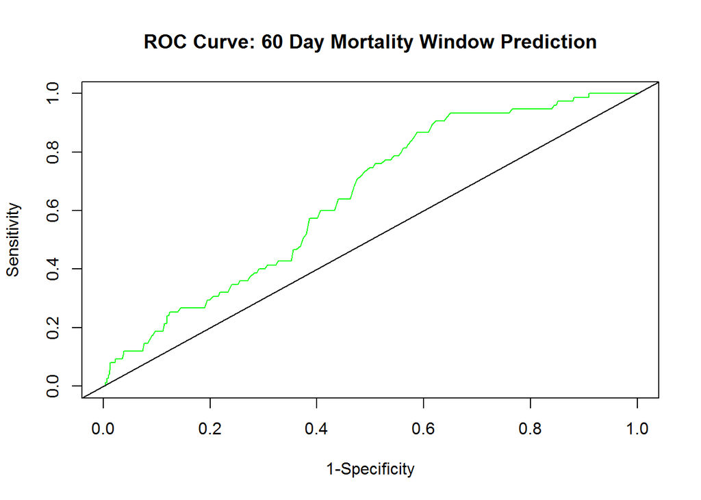

```
## integer(0)
```

# Next Steps

I’d like to create a visualization showing densities of people with diagnoses, procedure, and survey phenotypes across who died and who lived. This would lead to an effective metric of what outcome care providers can expect, on average, from patients with different “phenotypes”. For example, graphing these averages across more detailed diagnostic criteria or location information might clarify what underaddressed conditions exist and what hospitals have more or less effective treatments. It’s also valuable to identify what treatment pathways people take which make patient disposition codes so predictive for 30 day mortality windows.

# Conclusion:

The AUC for the Balanced Random Forests were satisfactory for the 30 day methods; the 60-day method was less satisfactory, with lower AUC and higher OOB error rate (average error using predictions from datapoints that the trees do not contain in their samples). In future analysis I would implement Lasso or ENET classification to see what “unnecessary” predictors would be dropped, as well as include more survey variables, like diet. Overall, though the analysis showed that mortality after discharge is strongly rooted in patient disease states, with a moderate component in general health and healthy lifestyle decisions.